# Bioinformatics_Assignment

Ilke Demirci

2023-03-08

# Assignment 1 – Literature

1. What is the medically relevant insight from the article? Ovarian cancer causes changes in the cervicovaginal microbiota where the Lactobacillus strain is low level, although the microbiota is more diverse in terms of several different strains of bacteria, regardless of menopausal status. A similar effect was observed in the postmenopausal donors.
2. Which genomics technology/ technologies were used? DNA extraction from the cervical smear samples for both malignant and bening tumors was performed. 16s rRNA gene amplicons were also sequencer with the MiSeq platform. The data was first demultiplexed and stitched together to reconstruct the amplicons, followed by filtering out low quality reads. Further data processing was done in order to trim adapter and primer sequences. Subsequently, the dataset was analyzed with QIIME data analysis tool. Machine learning algorithms were also used in order to distinguish premenopausal and postmenopausal cervicovaginal microbiota.
3. Further related research questions List and explain at least three questions/ hypotheses you can think of that extend the analysis presented in the paper.
- Does microbiota composition of the cervicovaginal environment change with age at different stages that affect reproduction (i.e. puberty, premenopausal and postmenopausal stages)? This question can be answered by collecting longitudinal smear samples from donors spanning at least 2 of these 3 stages.
- The relationship between the microbiota change and ovarian cancer can be further investigated. Does the decrease in Lactobacillus content and the increase in microbiota diversity which were observed in ovarian cancer have a causal effect for cancer?
- What is the mechanistic effect of hormone replacement therapy in postmenopausal donors in terms of microbiota diversity and cancer outcomes? If the change in microbiota diversity is related to the decline in some of the female reproductive hormones such as estrogen, can the microbiota be reversed to premenopausal characteristics with hormone replacement therapy? And what would be the prevalence of ovarian cancer in such patients?

#Task4 - Basic R operations

```r
#square root of 10
sqrt(10)
```

```
## [1] 3.162278
```

```r
#logarithm of 32 to the base 2
log2(32)
```

```
## [1] 5
```

```r
log(32)/log(2)
```

```
## [1] 5
```

```r
#sum of the numbers from 1 to 1000
sum(1:1000)
```

```
## [1] 500500
```

```r
#sum of all even numbers from 2 to 1000
x = seq(from = 2, to = 1000, by = 2) #create a variable to save even integers from 2 to 1000
sum(x) #sum integers
```

```
## [1] 250500
```

```r
#How many pairwise comparisons are there for 100 genes
choose(100,2)
```

```
## [1] 4950
```

```r
#how many ways to arrange 100 genes in triples
choose(100,3)
```

```
## [1] 161700
```

#Task 5 - Using R example datasets

```r
#load data CO2
data("CO2")
```

```r
#Describe briefly the content of the CO2 dataset using the help function
help(CO2)
#The CO2 data frame has 84 rows and 5 columns of data from an experiment on the cold tolerance of the grass species Echinochloa crus-galli.
```

```r
#average and median CO2 uptake of the plants from Quebec and Mississippi
mean(CO2$uptake[CO2$Type == "Quebec"])
```

```
## [1] 33.54286
```

```r
mean(CO2$uptake[CO2$Type == "Mississippi"])
```

```
## [1] 20.88333
```

```r
median(CO2$uptake[CO2$Type == "Quebec"])
```

```
## [1] 37.15
```

```r
median(CO2$uptake[CO2$Type == "Mississippi"])
```

```
## [1] 19.3
```

#Task 6 - R Functions

```r
#function that calculates the ratio of the mean and the median of a given vector
ratio <- function(x) mean(x)/median(x)
```

```r
#function that ignores the lowest and the highest value from a given vector and calculate the mean
mean_without <- function(x) { #define function mean_without
  x = x[x != min(x)] #exclude all minimums in vector x
  x = x[x != max(x)] #exclude all maximums in vector x
  mean(x) #calculate mean of x with the defined exclusions
}
```

#Piping

Pipes are a way to perform multiple transformations on a piece of data which is readable and computationally efficient. The pipe command, `%>%`, is very useful if you have a linear series of operations to perform on a single object. If you need to transform multiple objects or have a set of operations which are not linear and ordered other approaches should be considered. If you have many transformations to perform, consider breaking the pipe up into multiple intermediate steps.

#The apply-family of functions

The apply family of functions is a way to perform a particular function on a set of data. The main difference between apply functions is which kind of objects they take as input and return as output. They may be very useful for quickly and succinctly performing a certain operation on every item in a dataset without writing out a for loop.

#Task 7 - Basic visualization with R

```r
#Compare the distributions of the body heights of the two species from the 'magic_guys.csv' dataset graphically
magic_guys <- read.csv("magic_guys.csv")
```

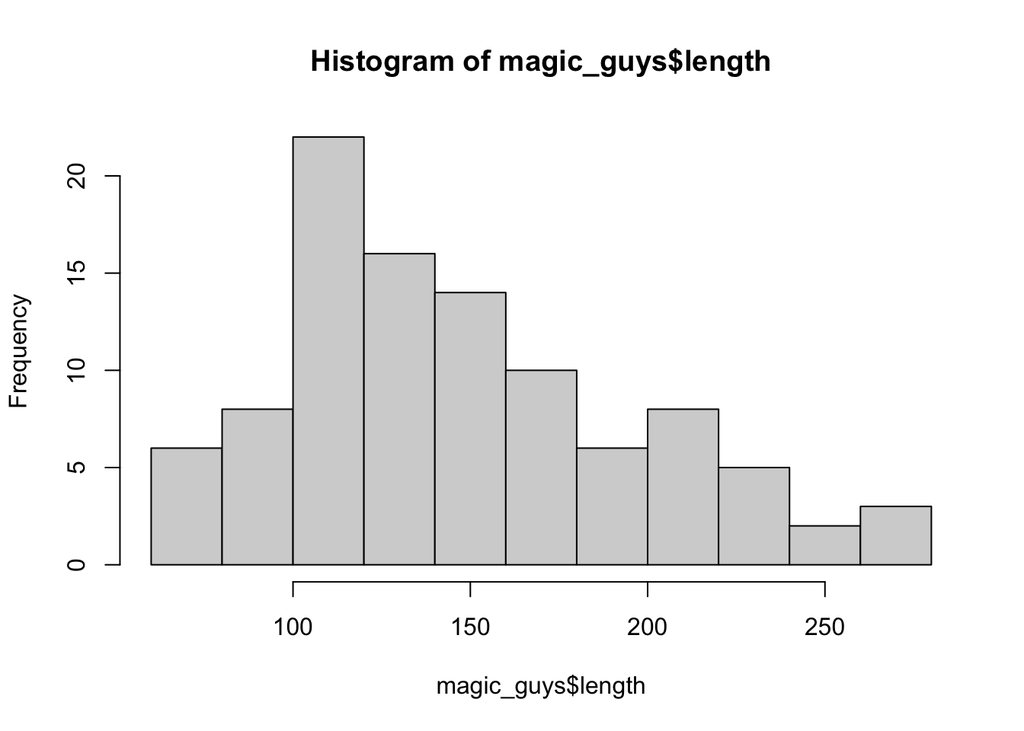

```r
hist(magic_guys$length)
```

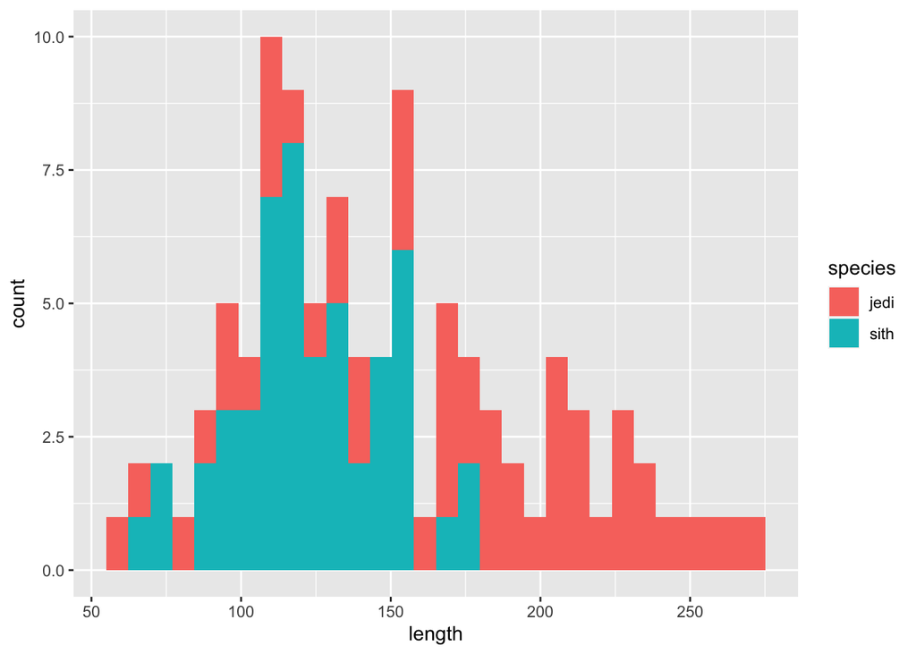

```r
library(ggplot2)
library(dplyr)
p <- ggplot(magic_guys, aes(fill=species, x=length))
p + geom_histogram()
```

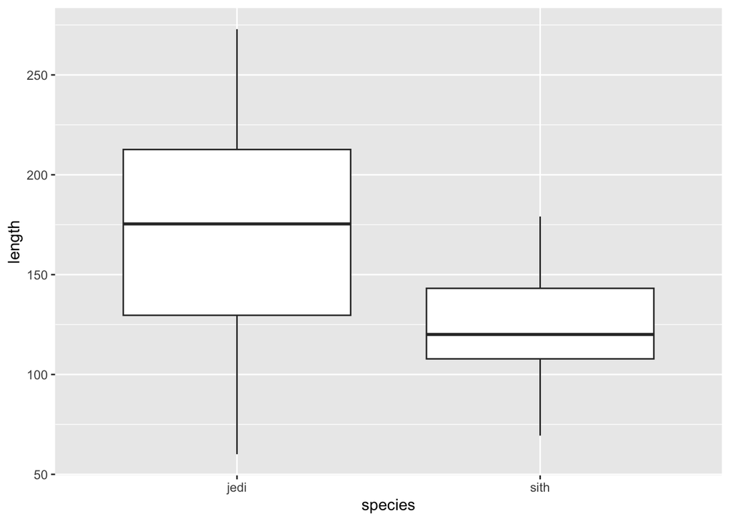

```r
p <- ggplot(magic_guys, aes(x=species, y=length))
p + geom_boxplot()
```

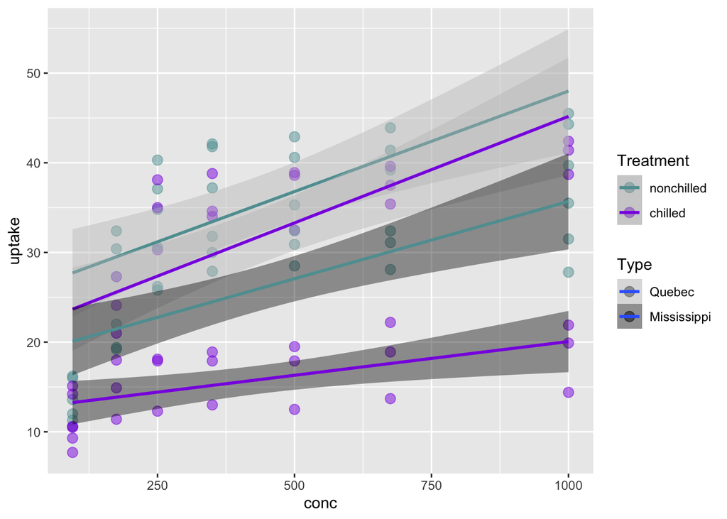

```r
ggplot(CO2, aes(x=conc, y=uptake, fill=Type, color=Treatment)) +
  geom_point(alpha=0.50, size=3) +
  geom_smooth(method=lm, aes(fill=Type)) +
  scale_color_manual(values = c("cadetblue", "blueviolet")) +
  scale_fill_manual(values = c("grey", "black"))
```

```r
library(tidybiology)
```

```r
chromosome %>% summarise(across(c(variations, protein_codinggenes, mi_rna), list(mean = ~mean(.x, na.rm = TRUE),median = ~median(.x, na.rm = TRUE), max = ~max(.x, na.rm = TRUE))))
```

```
## # A tibble: 1 × 9
##   variations_m…¹ varia…² varia…³ prote…⁴ prote…⁵ prote…⁶ mi_rn…⁷ mi_rn…⁸ mi_rn…⁹
##            <dbl>   <dbl>   <dbl>   <dbl>   <dbl>   <int>   <dbl>   <dbl>   <int>
## 1       6484572. 6172346  1.29e7    850.     836    2058    73.2      75     134
## # … with abbreviated variable names ¹variations_mean, ²variations_median,
## #   ³variations_max, ⁴protein_codinggenes_mean, ⁵protein_codinggenes_median,
## #   ⁶protein_codinggenes_max, ⁷mi_rna_mean, ⁸mi_rna_median, ⁹mi_rna_max
```